# Chapter2.3_Collinearity

In this exercise we will look at the issue of collinearity in multivariate regression.

```r
library(tidyverse)
library(ISLR)
set.seed(1)
mydata <- data.frame(x1=runif(100),
x2=0.5*x1+rnorm(100)/10,
y=2+2*x1+0.3*x2+rnorm(100))
```

The correlation between x1 and x2 is high: 0.8351212. We can also see this with a simple scatterplot.

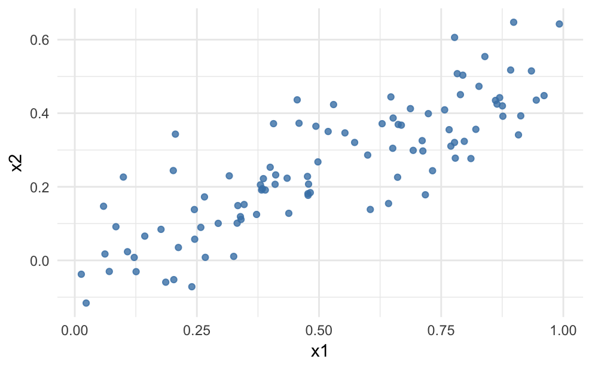

```r
ggplot(mydata, aes(x1, x2)) +
  geom_point(color="steelblue", alpha=0.8) +
  theme_minimal()
```

Now, we’ll fit a least squares regression to predict `y` usig `x1` and `x2`.

```r
summary(model)
```

```
Call:
lm(formula = y ~ x1 + x2, data = mydata)

Residuals:
    Min      1Q  Median      3Q     Max
-2.8311 -0.7273 -0.0537  0.6338  2.3359

Coefficients:
            Estimate Std. Error t value Pr(>|t|)
(Intercept)   2.1305     0.2319   9.188 7.61e-15
x1            1.4396     0.7212   1.996   0.0487
x2            1.0097     1.1337   0.891   0.3754

(Intercept) ***
x1          *
x2
---
Signif. codes:
0 ‘***’ 0.001 ‘**’ 0.01 ‘*’ 0.05 ‘.’ 0.1 ‘ ’ 1

Residual standard error: 1.056 on 97 degrees of freedom
Multiple R-squared:  0.2088,    Adjusted R-squared:  0.1925
F-statistic:  12.8 on 2 and 97 DF,  p-value: 1.164e-05
```

The results show that `x1` seems to have a statistically signicant influence on `y`, but `x2` does not. Overall, the R2 indicates that this model is not a particularly ‘good fit’ for explaining `y`.

However, if we run linear regressions separately, we can see that there is a relationship.

```r
model2 <- lm(data = mydata, y ~ x1)
summary(model2)
```

```
Call:
lm(formula = y ~ x1, data = mydata)

Residuals:
     Min       1Q   Median       3Q      Max
-2.89495 -0.66874 -0.07785  0.59221  2.45560

Coefficients:
            Estimate Std. Error t value Pr(>|t|)
(Intercept)   2.1124     0.2307   9.155 8.27e-15 ***
x1            1.9759     0.3963   4.986 2.66e-06 ***
---
Signif. codes:  0 ‘***’ 0.001 ‘**’ 0.01 ‘*’ 0.05 ‘.’ 0.1 ‘ ’ 1

Residual standard error: 1.055 on 98 degrees of freedom
Multiple R-squared:  0.2024,    Adjusted R-squared:  0.1942
F-statistic: 24.86 on 1 and 98 DF,  p-value: 2.661e-06
```

```r
model3 <- lm(data = mydata, y ~ x2)
summary(model3)
```

```
Call:
lm(formula = y ~ x2, data = mydata)

Residuals:
     Min       1Q   Median       3Q      Max
-2.62687 -0.75156 -0.03598  0.72383  2.44890

Coefficients:
            Estimate Std. Error t value Pr(>|t|)
(Intercept)   2.3899     0.1949   12.26  < 2e-16 ***
x2            2.8996     0.6330    4.58 1.37e-05 ***
---
Signif. codes:  0 ‘***’ 0.001 ‘**’ 0.01 ‘*’ 0.05 ‘.’ 0.1 ‘ ’ 1

Residual standard error: 1.072 on 98 degrees of freedom
Multiple R-squared:  0.1763,    Adjusted R-squared:  0.1679
F-statistic: 20.98 on 1 and 98 DF,  p-value: 1.366e-05
```

As the results above show, when multicollinearity exists, the following problems can be exacerbated:

- The estimated regression of any one variable depeneds on which variables are included in the model;
- The precision of the estimated regression coefficients decrease as more predictors are added to the model;
- The marginal contribution of any one predictor variable in reducing the error sum of squares depends on which other predictors are already in the model;
- Hypothesis tests may yield different conclusions depending on which predictors are in the model.

There are a number of actions available to us to deal with collinearity:

- Remove the correlated variables from the analysis;
- Use partial least squares regression or principal components analysis to reduce the number of features;
- Collect more data.